# Analyzing the Determinants of Academic Performance:An Analysis Of the Factors that Influence Sucess in Portuguese

Author

Keren Omari-Baah

Published

January 28, 2024

```r
exam_data <- read_csv("exam_data.csv")
```

# Introduction

Education a plays an important role in the social development and growth of individuals, which influences their future opportunities and life trajectories. In recent years, the educational sector has undergone significant transformation and understanding what determines academic success has therefore become necessary for educators, policymakers, and researchers. This report delves into an in-depth analysis of student achievement in secondary education within two Portuguese schools, with the aim of identifying various demographic, social, and school-related factors that have impact on academic performance in Mathematics and Portuguese language studies.

The dataset in this study consists of variables, ranging from student grades to their socio-economic backgrounds, collected through school reports and questionnaires. We will deal with two specific tasks in our analysis. The first task involves constructing a predictive model for the initial period grade in Portuguese (G1.Port) without any other grade features. However, we will include variables such as `freetime`, `schoolsup`, paid.Math, and `Dalc`, `sex`, `age`, `famsize`, `Medu`, `Fedu`, travel time, `studytime`, `Pstatus`, absences, activities and exclude reasons for school choice. The second task requires the transformation of the G1.Port grade into a categorical variable divided into three bins, each containing approximately equal numbers of cases. This newly categorized variable will serve as the response variable in a classification model with the same variable inclusion and exclusion criteria as the first task.

Our goal is to gain insights to what influences academic sucess by examining a wide range of factors, from familial to personal habits in these two subjects. Moreover, it seeks to contribute to the broader discourse on education by identifying key factors that can be addressed to enhance student achievement.

The methodology section that follows will detail the data pre processing steps, including the handling of missing values, exclusion of some variables, and the rationale behind the chosen techniques. This will set the foundation for the subsequent analysis and discussion of the results, which will help us understanding of the predictors of academic success in these two Portugual secondary schools.

# Background of Data

The dataset offers view of student life and their achievement in two Portuguese schools: Gabriel Pereira (GP) and Mousinho da Silveira (MS) which was carefully compiled through a combination of school reports and student questionnaires. The dataset is not only about academic performance but also provides a look into the socio-economic and personal features of the students’ lives. It encompasses a wide range of variables, grouped into several categories:

- The demographic information of the students which include the basic student data such as school (GP or MS), sex, age, and their home address.
- The students’ family background with variables like family size, parents’ cohabitation status, education levels of parents, and parents’ occupations fall under this category.
- Personal and social factors that are related to each student. This category covers information such as the student’s travel time to school, weekly study time, participation in extracurricular activities, romantic relationships, health and lifestyle choices including alcohol consumption.
- Apart from grades in Portuguese (like G1.Port) and Mathematics, the dataset also includes academic deatail such information on past class failures, school absences, and whether the student received any extra educational support.
- School-related features like reasons for choosing the particular school, the student’s guardian, failed classes and whether the student had access to resources like internet at home or had attended nursery school.

The two unique aspects of this dataset is that it focuses on academic perspective and a comprehensive range of non-academic variables. First, it provides grades for two the subjects, Mathematics and Portuguese, with a suffix indicating the subject (e.g., `G1.Math`, `G1.Port`). This is significant because it allows us to analyze the different academic disciplines. Secondly, the wide spread socio-economic, familial, and personal factors allows us to properly view the students’ educational environment and its impact on their academic achievements. This is important because we can use this data to build predictive models that can identify students at risk of underperforming.

1. `School` indicates the student’s school, either Gabriel Pereira (GP) or Mousinho da Silveira (MS).
2. `Sex` states the student’s gender, either female (F) or male (M).
3. `Age` represents the student’s age, which ranges from 15 to 22 years.
4. `Address` categorizes the student’s home address as urban (U) or rural (R).
5. `Famsize` refers to the family size, classified as less or equal to 3 (LE3) or greater than 3 (GT3).
6. `Pstatus` describes the parents’ cohabitation status, either living together (T) or apart (A).
7. `Medu` secifies the mother’s education level, with options ranging from 0 (none) to 4 (higher education).
8. `Fedu` specifies the father’s education level, also ranging from 0 (none) to 4 (higher education).
9. `Mjob` specifies the mother’s job, with categories like teacher, health care related, services, at_home, or other.
10. `Fjob` specifies the father’s job, with similar categories as `Mjob`.
11. `Guardian` specifies who the student’s guardian is, options being mother, father, or other.
12. `Traveltime` measures the time taken for the student to travel from home to school, ranging from less than 15 minutes to over an hour.
13. `Studytime` is the student’s weekly study time, from less than 2 hours to more than 10 hours.
14. `Failures` counts the number of past class failures, with a special category for 3 or more failures.
15. `Schoolsup` indicates whether the student receives extra educational support, with options yes or no.
16. `Famsup` tell us if there is family educational support available to the student, again with yes or no options.
17. `Paid` shows if the student takes extra paid classes within the course subject, answerable with yes or no.
18. `Activities` shows whether the student participates in extra-curricular activities, with possible responses being yes or no.
19. `Nursery` indicates whether the student attended nursery school, with a simple yes or no answer.
20. `Higher` reflects the student’s aspiration for higher education, answerable as yes or no.
21. `nternet` tell us if the student has internet access at home, with options yes or no.
22. `Romantic` discloses if the student is in a romantic relationship, answerable as yes or no.
23. `Famrel` rates the quality of family relationships on a scale from 1 (very bad) to 5 (excellent).
24. `Freetime` assesses the amount of free time the student has after school, on a scale from 1 (very low) to 5 (very high).
25. `Goout` measures the frequency of how many tmes a student goes out with friends, rated from 1 (very low) to 5 (very high).
26. `Dalc` measures workday alcohol consumption on a scale from 1 (very low) to 5 (very high).
27. `Walc` measures weekend alcohol consumption, also on a scale from 1 to 5.
28. `Health` evaluates the student’s current health status, on a scale from 1 (very bad) to 5 (very good).
29. `Absences` counts the number of school absences, ranging from 0 to 93.
30. `G1.Port` represents the student’s first period grade in Portuguese. The numeric scale ranges from 0 to 20, where 0 is the lowest and 20 is the highest possible score.
31. `G2.Port` represents the student’s second period grade in Portuguese, also on a scale from 0 to 20. It reflects the student’s performance in the middle of the academic term.
32. `G3.Port` is the final grade in Portuguese for the student, calculated on a scale from 0 to 20. It represents the overall achievement in Portuguese for the term or year.
33. `G1.Math` is the first period grade in Mathematics, on a scale from 0 to 20.
34. `G2.Math` is the second period grade in Mathematics, also on a numeric scale from 0 to 20.
35. `G3.Math` is the final grade in Mathematics, on a scale from 0 to 20.

# Data Preprocessing

In order to ensure that the data is accurate, consistent, and suitable for effective modeling and analysis, the data cleaned and organized the dataset. This involves analyzing the dataset to pinpoint any absent values and deciding on appropriate strategies, such as deletion of rows/columns, based on the nature and extent of the missing data with the aim of minimizing bias and maintain the integrity of the dataset for accurate analysis and modeling. First, missing data needs to be identified and addressed to ensure data quality and reliability.

```r
missing_values <- colSums(is.na(exam_data))
missing_values
```

```
         ...1        school           sex           age       address
            0             0             0             0             0
      famsize       Pstatus          Medu          Fedu          Mjob
            0             0             0             0             0
         Fjob        reason      guardian    traveltime     studytime
            0             0             0             0             0
    schoolsup        famsup    activities       nursery        higher
            0             0             0             0             0
     internet      romantic        famrel      freetime         goout
            0             0             0             0             0
         Dalc          Walc        health failures.Math     paid.Math
            0             0             0             0             0
absences.Math       G1.Math       G2.Math       G3.Math failures.Port
            0             0             0             0             0
    paid.Port absences.Port       G1.Port       G2.Port       G3.Port
            0             0             0             0             0
```

However, there are no missing values. Next, the column containing the unique ID is excluded,because it does not provide distinct values for each row, which is essential for it to serve as a meaningful variable in the analysis.

```r
exam_data <- exam_data %>% dplyr::select(- `...1`)
```

This exclusion is done removing redundant or irrelevant information that does not contribute to the analysis or could potentially skew the results. By focusing on variables that offer valuable insights, like different grades, the dataset’s relevance and the accuracy of our models is enhanced. This selective approach ensures that the analysis is based on variables that truly impact the outcomes we’re investigating, leading to more precise and actionable findings. Some exploratory variables are also transformed into categorical values. This process is essential for handling variables like `school`, `sex`, `Mjob`, and `Fjob`, which, although initially categorical, need to be converted into a numerical format to help the statistical modeling. This will make them compatible with various analytical techniques that require numerical input.

```r
exam_data <- exam_data %>%
  mutate(school = as.factor(school),
         sex = as.factor(sex),
         Mjob = as.factor(Mjob),
         Fjob = as.factor(Fjob))
```

Another step in data preprocessing was to split the dataset into training and testing sets as this is crucial for validating the performance of the models built. A 70-30 otest split was used to ensure that the models are trained on a large portion of the data and tested on an unseen subset.

```r
nrow_exam <- nrow(exam_data)
ncol_exam <- ncol(exam_data)

set.seed(1582)
train_indices <- sample(1:nrow_exam, round(0.7 * nrow_exam))
train_data <- exam_data[train_indices, ]
test_data <- exam_data[-train_indices, ]
view(train_data)
view(test_data)

train_data <- train_data[complete.cases(train_data), ]
test_data <- test_data[complete.cases(test_data), ]
```

```r
exam_data <- exam_data |>
  mutate(catG1 = cut(`G1.Port`, breaks = 3, labels = c("Low", "Medium", "High")))
```

# Data Exploration

For our data exploration we looked at all the bar plots and histogram for all the variables.

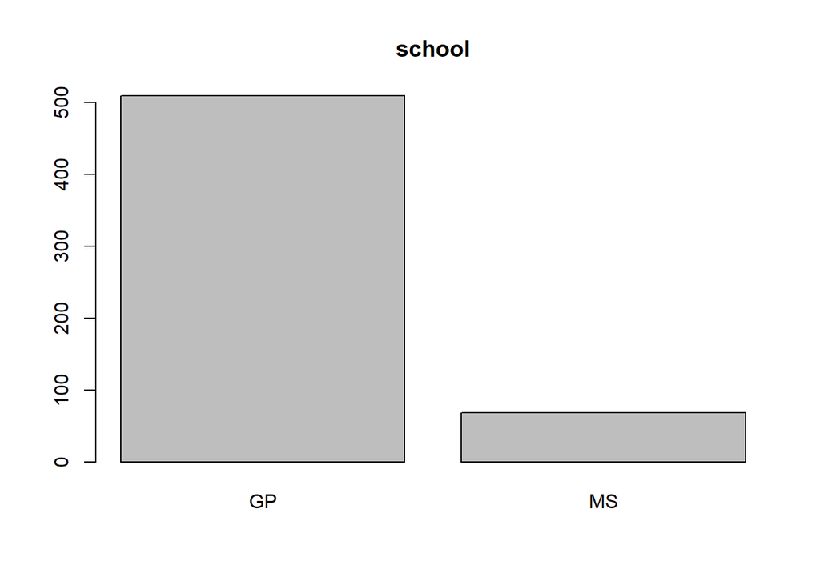

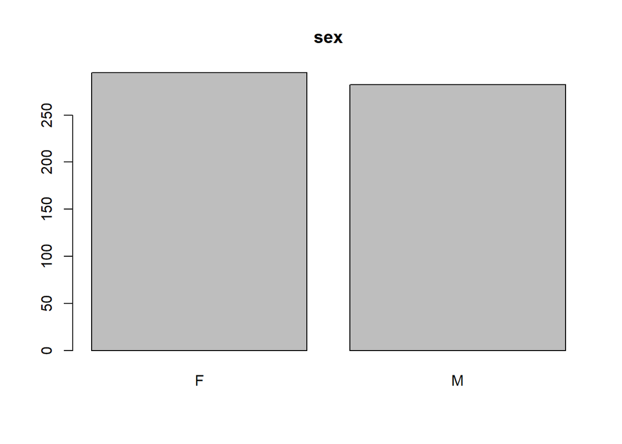

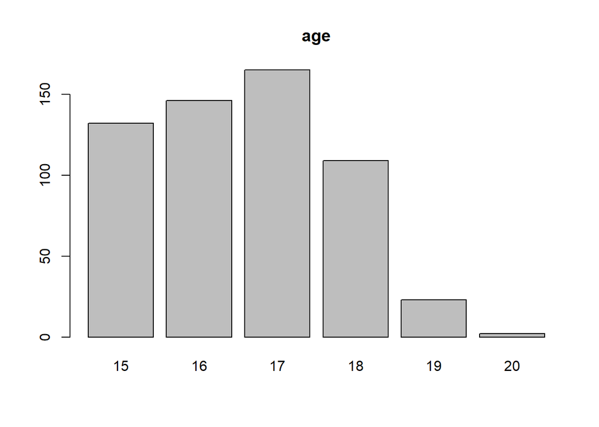

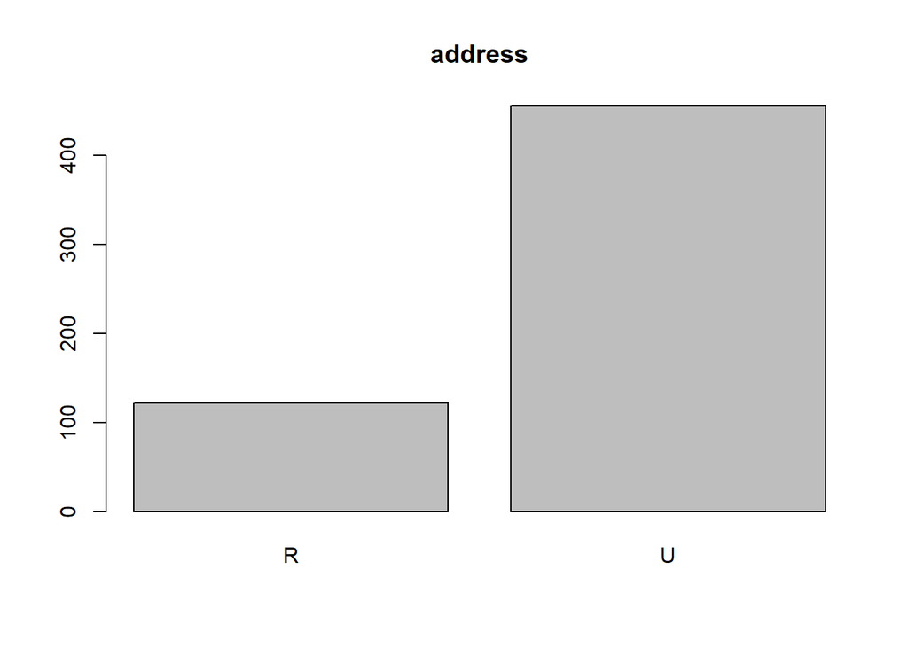

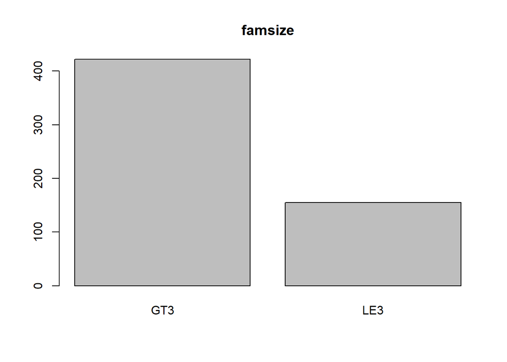

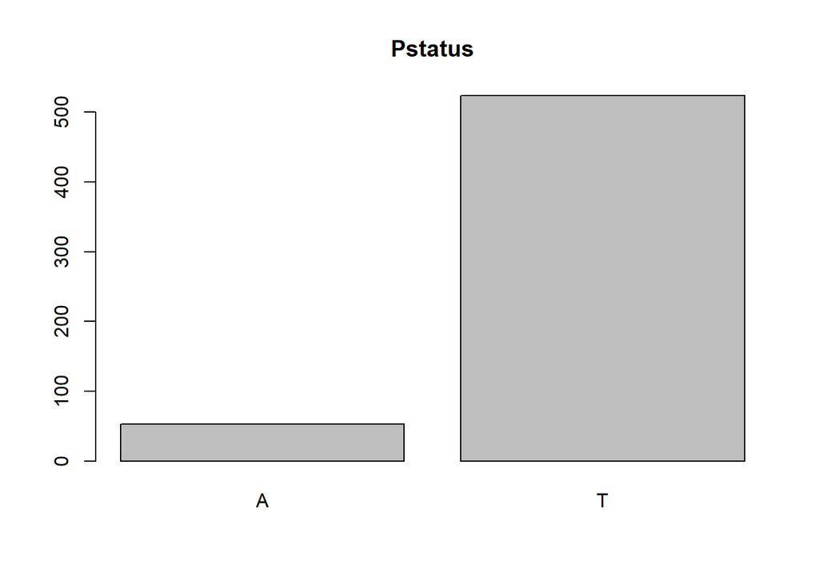

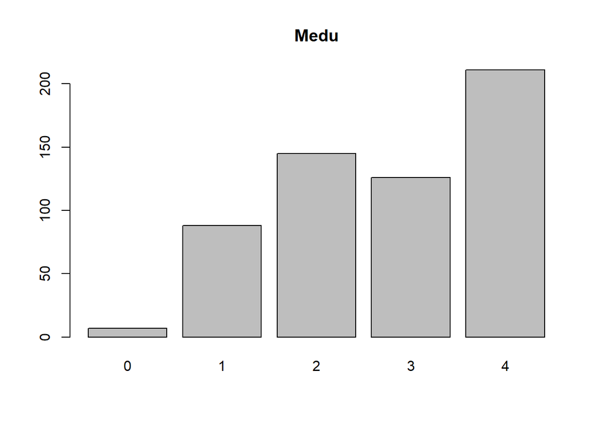

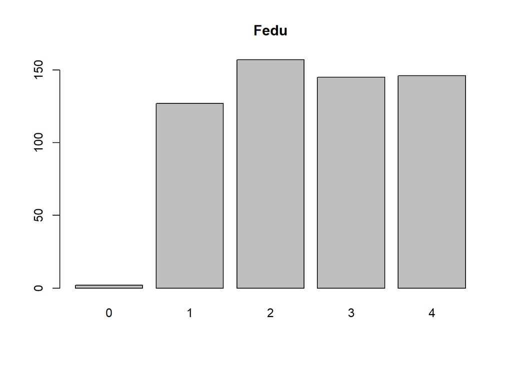

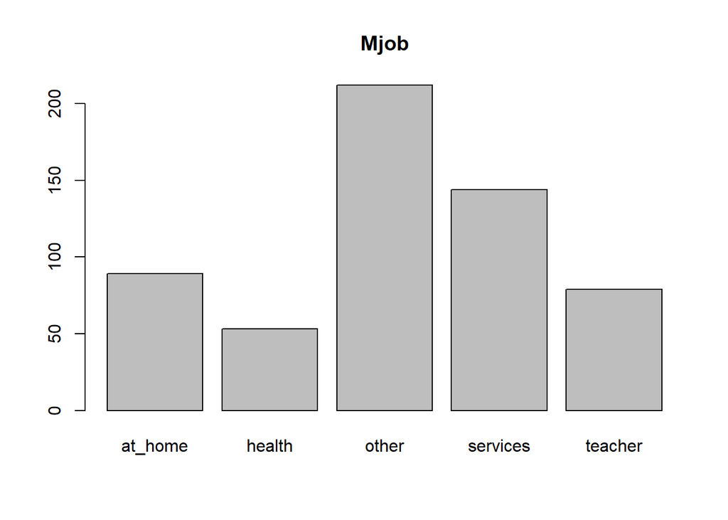

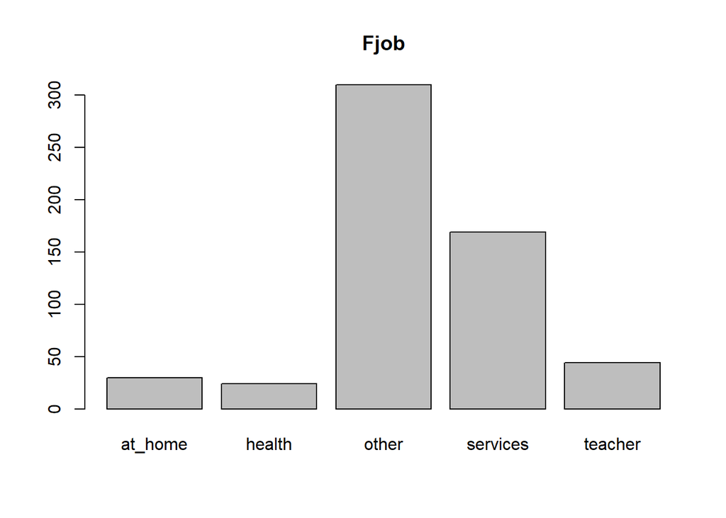

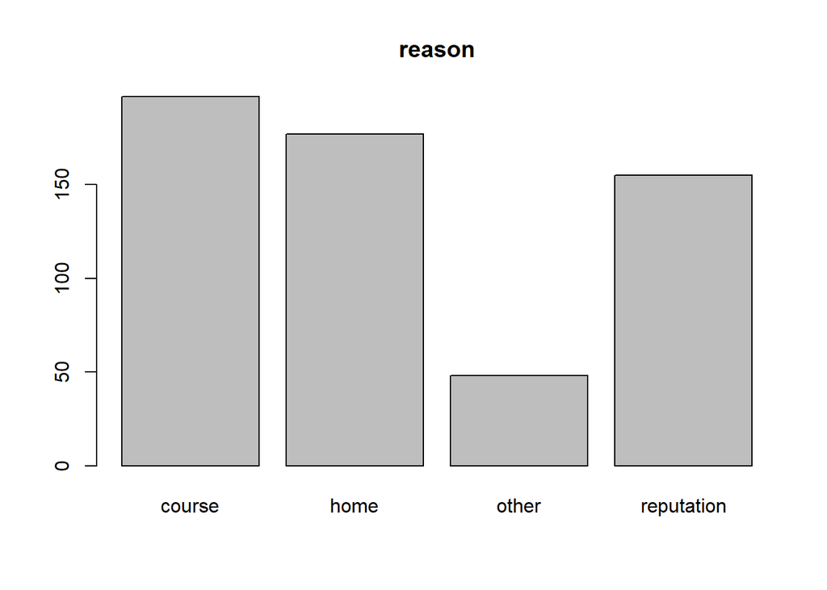

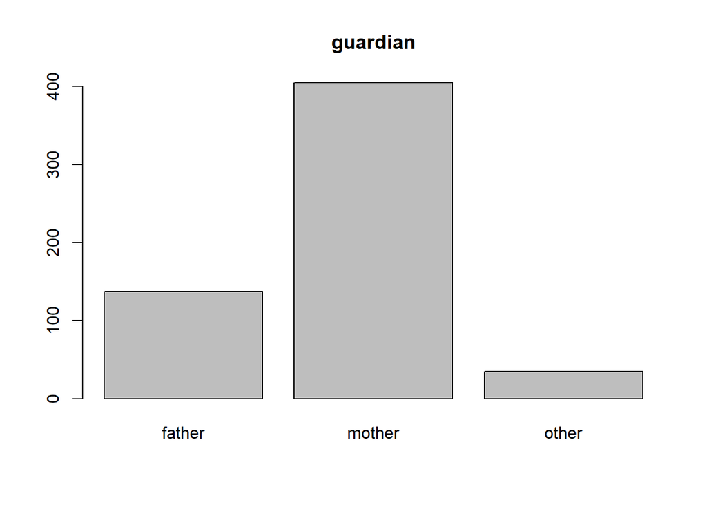

[27 more figures not shown]

```r
par(mfrow = c(1, 1))
for (i in 1:ncol_exam) {
  if (is.numeric(train_data[, i])) {
    hist(train_data[, i], main = names(train_data)[i], xlab = "")
  } else {
    barplot(table(train_data[, i]), main = names(train_data)[i])
  }
}
```

Now we present a box plot that shows the distribution of the grade in the first period G1 by a few explanatory variables.

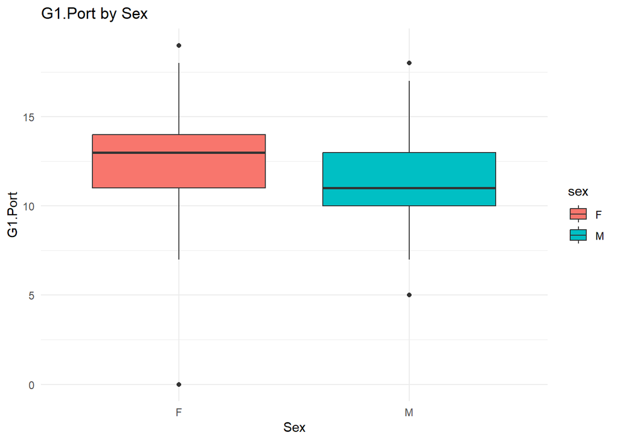

```r
ggplot(exam_data, aes(x = sex, y = G1.Port, fill = sex)) +
  geom_boxplot() +
  theme_minimal() +
  labs(title = "G1.Port by Sex", x = "Sex", y = "G1.Port")
```

This boxplot likely compares the grades of students who receive school support versus those who do not. The median of schools with no support is higher than that of those who receive support suggesting that school support has no significant impact on a student getting a good grade in Portuguese.

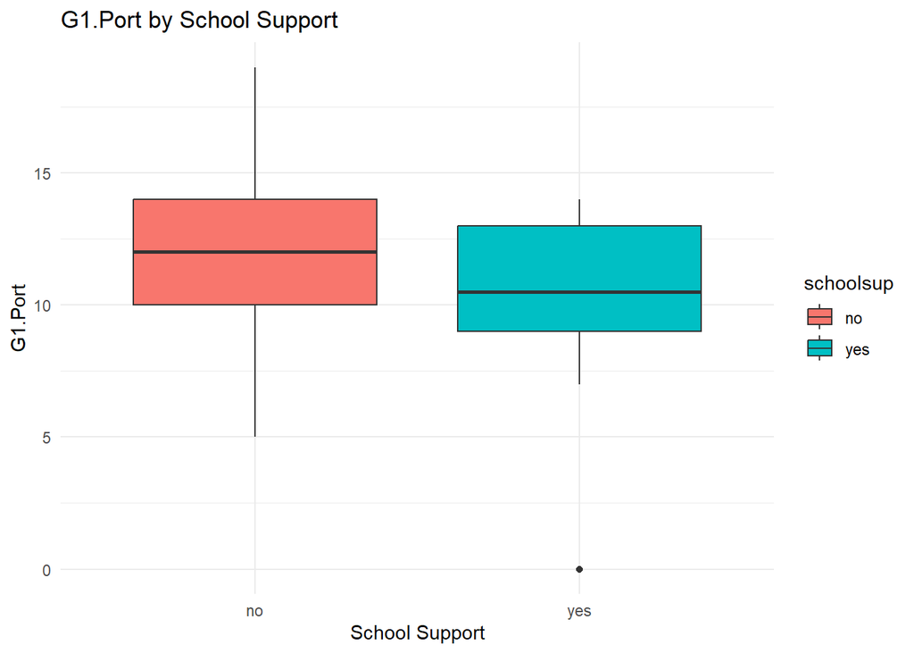

```r
ggplot(exam_data, aes(x = schoolsup, y = G1.Port, fill = schoolsup)) +
  geom_boxplot() +
  theme_minimal() +
  labs(title = "G1.Port by School Support", x = "School Support", y = "G1.Port")
```

The boxplot of G1.Port by school (GP and MS) shows that students in Gabriel Pereira perform better than students in Mousinho da Silveria.

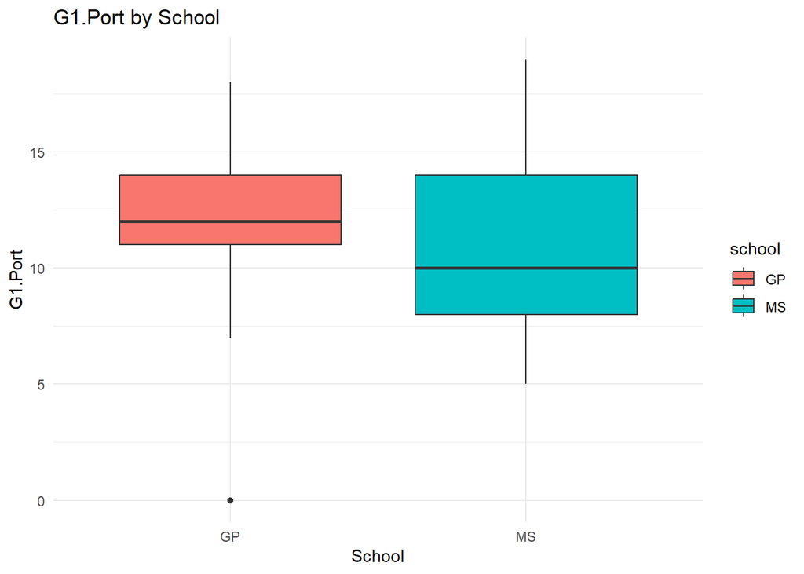

```r
ggplot(exam_data, aes(x = school, y = G1.Port, fill = school)) +
  geom_boxplot() +
  theme_minimal() +
  labs(title = "G1.Port by School", x = "School", y = "G1.Port")
```

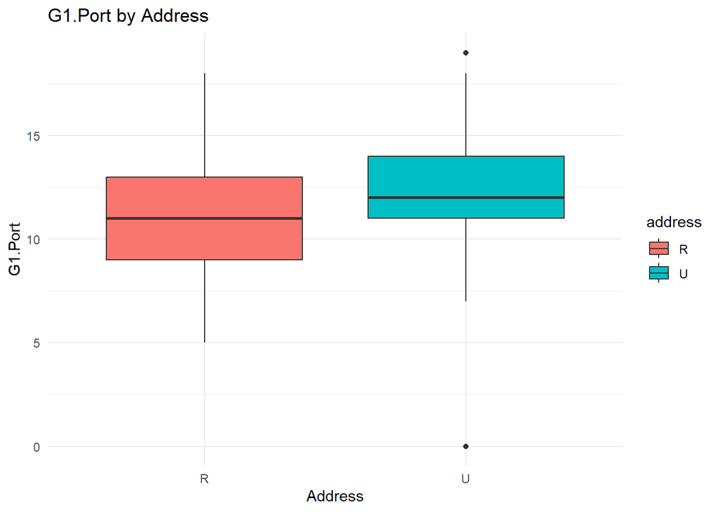

```r
ggplot(exam_data, aes(x = address, y = G1.Port, fill = address)) +
  geom_boxplot() +
  theme_minimal() +
  labs(title = "G1.Port by Address", x = "Address", y = "G1.Port")
```

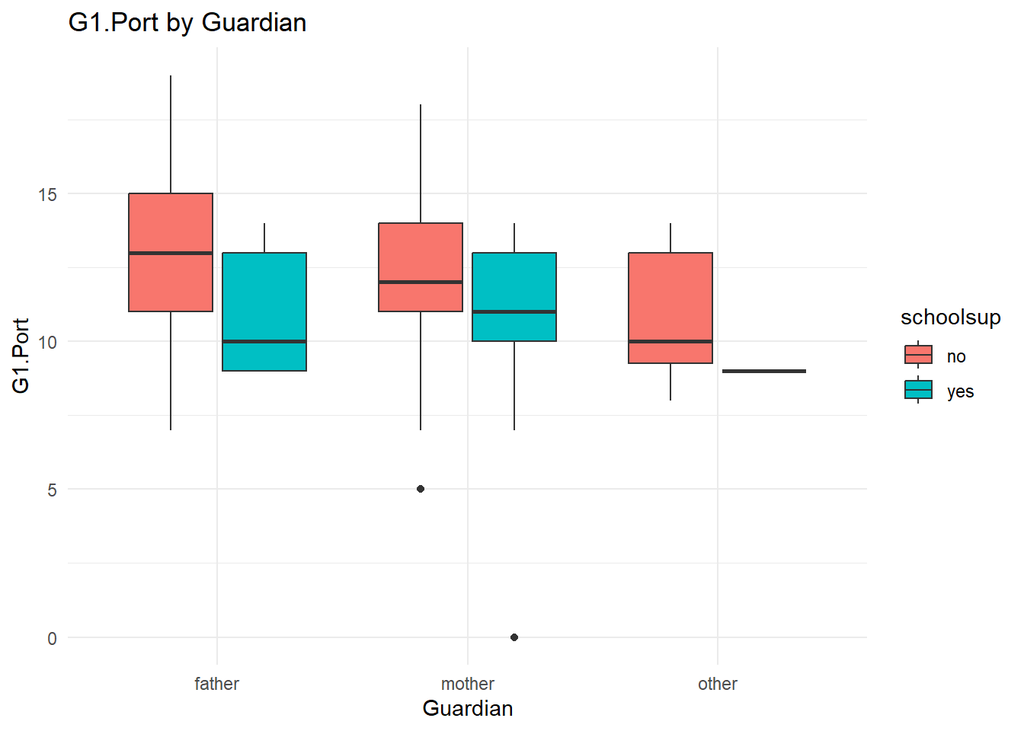

```r
ggplot(exam_data, aes(x = guardian, y = G1.Port, fill = schoolsup)) +
  geom_boxplot() +
  theme_minimal() +
  labs(title = "G1.Port by Guardian", x = "Guardian", y = "G1.Port")
```

# Data Analysis

### **Task 1: Predictive Modeling for G1.Port**

We developed a predictive model targeting the variable ‘G1.Port’, which represents the first period grade in Portuguese. This model was built without incorporating any other grade features, ensuring that our predictions are based solely on non-academic factors. The default model included the variables ‘freetime’ (amount of free time after school), ‘schoolsup’ (extra educational support), ‘paid.Math’ (extra paid classes in Mathematics), and ‘Dalc’ (workday alcohol consumption), while explicitly excluding the variable ‘reason’ for school choice. Our models aim to establish how these specific factors contribute to predicting a student’s performance in Portuguese, independent of their grades in other subjects. The effectiveness of our model is assessed using the R-squared value, which measures the proportion of variance in the dependent variable that is predictable from the independent variables.Therefore, an R-squared value closer to 1 indicates that the model explains a high proportion of the variance in the target variable, while a value closer to 0 suggests less explanatory power.

To solve our first task we will fit a linear regression model with `G1.Port` as the response variable and `freetime`, `schoolsup`, `paid.math`, `Dalc`, and as the explanatory variables.

```r
exam_lm <- lm(`G1.Port` ~ freetime + schoolsup + `paid.Math` + Dalc , data = train_data)
summary(exam_lm)
```

```
Call:
lm(formula = G1.Port ~ freetime + schoolsup + paid.Math + Dalc,
    data = train_data)

Residuals:
     Min       1Q   Median       3Q      Max
-10.8311  -1.6117   0.0094   1.6569   6.3883

Coefficients:
             Estimate Std. Error t value Pr(>|t|)
(Intercept)   13.7994     0.4060  33.992  < 2e-16 ***
freetime      -0.1343     0.1117  -1.202   0.2299
schoolsupyes  -1.7806     0.3197  -5.570 3.93e-08 ***
paid.Mathyes   0.3789     0.2137   1.773   0.0767 .
Dalc          -0.7848     0.1199  -6.544 1.34e-10 ***
---
Signif. codes:  0 '***' 0.001 '**' 0.01 '*' 0.05 '.' 0.1 ' ' 1

Residual standard error: 2.542 on 572 degrees of freedom
Multiple R-squared:  0.1247,    Adjusted R-squared:  0.1186
F-statistic: 20.38 on 4 and 572 DF,  p-value: 1.037e-15
```

```r
predictions <- predict(exam_lm, newdata = test_data)
view(predictions)

accuracy <- sqrt(mean((test_data$G1.Port - predictions)^2))
print(paste("Root Mean Squared Error (RMSE):", accuracy))
```

```
[1] "Root Mean Squared Error (RMSE): 2.49452784261822"
```

However, our adjusted R squared was not good enough so we added more variables for a second model, “exam_lm2”.

```r
exam_lm2 <- lm(`G1.Port` ~ studytime + `paid.Math` + schoolsup + sex + guardian + address  + internet + activities + school + freetime + Dalc, data =train_data)
summary(exam_lm2)
```

```
Call:
lm(formula = G1.Port ~ studytime + paid.Math + schoolsup + sex +
    guardian + address + internet + activities + school + freetime +
    Dalc, data = train_data)

Residuals:
     Min       1Q   Median       3Q      Max
-10.6358  -1.4297  -0.1961   1.4362   6.5850

Coefficients:
                Estimate Std. Error t value Pr(>|t|)
(Intercept)    12.166619   0.582859  20.874  < 2e-16 ***
studytime       0.355884   0.121881   2.920 0.003641 **
paid.Mathyes   -0.081263   0.207026  -0.393 0.694819
schoolsupyes   -2.209327   0.298256  -7.407 4.72e-13 ***
sexM           -1.135955   0.222888  -5.097 4.73e-07 ***
guardianmother -0.796741   0.237824  -3.350 0.000862 ***
guardianother  -1.743306   0.445078  -3.917 0.000101 ***
addressU        1.259771   0.268684   4.689 3.45e-06 ***
internetyes     0.642811   0.275480   2.333 0.019976 *
activitiesyes   0.157091   0.201398   0.780 0.435716
schoolMS       -0.767722   0.337875  -2.272 0.023450 *
freetime        0.001817   0.106976   0.017 0.986451
Dalc           -0.501706   0.115090  -4.359 1.55e-05 ***
---
Signif. codes:  0 '***' 0.001 '**' 0.01 '*' 0.05 '.' 0.1 ' ' 1

Residual standard error: 2.324 on 564 degrees of freedom
Multiple R-squared:  0.2782,    Adjusted R-squared:  0.2629
F-statistic: 18.12 on 12 and 564 DF,  p-value: < 2.2e-16
```

```r
predictions <- predict(exam_lm, newdata = test_data)
view(predictions)

accuracy <- sqrt(mean((test_data$G1.Port - predictions)^2))
print(paste("Root Mean Squared Error (RMSE):", accuracy))
```

```
[1] "Root Mean Squared Error (RMSE): 2.49452784261822"
```

Conversely, an increase in workday alcohol consumption (Dalc) appears to have a detrimental effect, with the model indicating that each unit increase in Dalc leads to an average decrease of 0.501 in the G1.Port grade. This negative correlation reflects the adverse impacts of alcohol consumption on aspects such as health and focus, which are crucial for academic success.

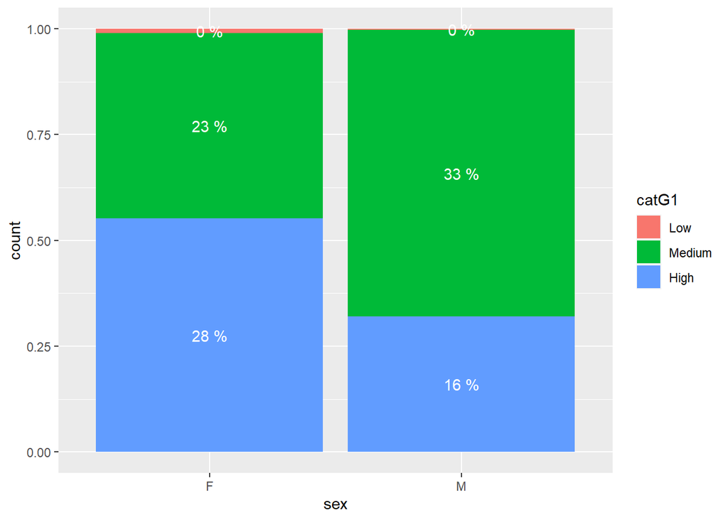

```r
ggplot(exam_data, aes(x=sex, fill = catG1)) +
  geom_bar(position = "fill") +
  stat_count(geom = "text",
             aes(label = paste(round((..count..)/sum(..count..)*100), "%")),
             position=position_fill(vjust=0.5), colour="white")
```

```r
cat_exam_glm <- multinom(`G1.Port` ~ freetime + schoolsup + `paid.Math` + Dalc, data = train_data)
summary(cat_exam_glm)
```

```
Call:
multinom(formula = G1.Port ~ freetime + schoolsup + paid.Math +
    Dalc, data = train_data)

Coefficients:
   (Intercept)    freetime schoolsupyes paid.Mathyes      Dalc
7    1.3430859  0.50470077    -18.08765    12.203692 12.963168
8    0.7362201  0.73008623    -41.18831    12.046521 13.033924
9    4.1725855 -0.11685065    -15.86718    11.308386 13.087890
10   4.4833669  0.13372728    -16.86547    12.562336 12.688088
11   5.0083749 -0.14436694    -17.98213    12.818912 12.804876
12   4.7892396  0.15683999    -17.24014    13.197999 12.332025
13   6.2459784 -0.02670839    -16.94323    12.516615 11.847252
14   6.3304925 -0.02410838    -18.36249    12.452832 11.817584
15   6.1024272 -0.16197346    -37.04127    12.937348 11.735714
16  23.6176124  0.50878592    -41.88142    13.265553 -8.797983
17   4.4061424  0.04153925    -42.12679    12.102903 12.489614
18   3.6142753  0.02488465    -44.20193    13.722617 11.438717
19  19.7921754 -0.14750576    -38.39302    -2.702685 -2.965258

Std. Errors:
   (Intercept)  freetime schoolsupyes paid.Mathyes      Dalc
7    1.2092297 0.7192980 1.398796e+00 4.995690e-01 0.5835624
8    1.1977326 0.7117678 2.661397e-09 4.552384e-01 0.5761200
9    0.7574425 0.6674865 1.040151e+00 3.696675e-01 0.5661969
10   0.7033505 0.6660290 1.040603e+00 2.426220e-01 0.5611438
11   0.7172437 0.6706154 1.090773e+00 2.574595e-01 0.5617633
12   0.7054696 0.6666815 1.048300e+00 2.339271e-01 0.5651651
13   0.7071022 0.6635728 1.034989e+00 2.417358e-01 0.5859687
14   0.7335166 0.6692856 1.107930e+00 2.520998e-01 0.5905287
15   0.8404532 0.6800778 3.727595e-07 3.153304e-01 0.6263953
16   0.7276574 0.7088651 9.769646e-10 4.657384e-01 0.7276574
17   0.9198342 0.6911620 1.344706e-09 3.936823e-01 0.5907600
18   1.7258401 0.7704056 4.416560e-11 7.759164e-01 1.0105701
19   0.8510916 0.7879930 1.601076e-08 2.234834e-07 0.8510919

Residual Deviance: 2481.018
AIC: 2611.018
```

```r
predictions_lm_final <- predict(cat_exam_glm, newdata = test_data)
#view(predictions)
accuracy_lm_final <- sqrt(mean((test_data$G1.Port - predictions_lm_final)^2))
accuracy_lm_final
```

```
[1] NA
```

```r
predictions_cat_glm <- predict(cat_exam_glm, newdata = test_data, type = "class")
accuracy_glm_final <- sqrt(mean((test_data$G1.Port - predictions_lm_final)^2))
accuracy_glm_final
```

```
[1] NA
```

Doing the same for this model as in task 1, we added a few more variables to get a better model.

```r
cat_exam_glm <- multinom(`G1.Port` ~ studytime + schoolsup + sex + guardian + address  + internet + activities + school + freetime + Dalc +freetime + `paid.Math` , data = train_data)
summary(cat_exam_glm)
```

```
Call:
multinom(formula = G1.Port ~ studytime + schoolsup + sex + guardian +
    address + internet + activities + school + freetime + Dalc +
    freetime + paid.Math, data = train_data)

Coefficients:
   (Intercept) studytime schoolsupyes       sexM guardianmother guardianother
7    33.368282  10.37222    -25.89104 20.5874349      -8.308311     -35.38060
8    29.472980  12.50585    -97.68774 20.3829099      -7.547312      27.35352
9    33.532356  12.24534    -24.66789 23.1707336      -9.807225      25.88993
10   31.790080  13.39830    -26.46048 20.8260840      -9.541477      25.66730
11   32.119469  13.09513    -28.09054 20.1793701      -8.953037      24.80101
12   33.665581  12.88802    -27.40723 20.1223869      -9.945369      24.21518
13   34.703147  13.10278    -27.06464 20.1359262      -9.781484      24.36263
14   34.061688  12.95433    -28.80369 19.1817671     -10.202266      24.27649
```

[output cut: 80 more lines]

```r
predictions_lm_final <- predict(cat_exam_glm, newdata = test_data)
#view(predictions)
accuracy_lm_final <- sqrt(mean((test_data$G1.Port - predictions_lm_final)^2))
accuracy_lm_final
```

```
[1] NA
```

```r
predictions_cat_glm <- predict(cat_exam_glm, newdata = test_data, type = "class")
accuracy_glm_final <- sqrt(mean((test_data$G1.Port - predictions_lm_final)^2))
accuracy_glm_final
```

```
[1] NA
```

For this classification model, the interpretation of R-squared is slightly different, as it is typically used for regression analyses. However, if an analogous measure is used (like pseudo R-squared in logistic regression), it can still provide insights into the model’s explanatory power. A higher value would suggest that our model is effective in categorizing students into the correct performance levels based on the given predictors.

#### **Interpretation of R-Squared Value:**

The R-squared value of 0.1186 for the first model suggests that it makes up approximately 11.86% of the variance in the grades. While this indicates some level of predictive power, a significant portion of the grade variability remains unexplained by the model. This could be due to the absence of key predictive variables and or the presence of other unaccounted factors influencing student performance.

In contrast, the second model, with an R-squared value of 0.2629, makes up of about 26.29% of the variance in the grades. This higher R-squared value indicates a better fit to the data compared to the first model, because includes variables that are more relevant or better capture the complexities influencing student grades in Portuguese.

However, it is important to interpret these R-squared values cautiously. A higher R-squared value, while generally desirable, is not an absolute measure of a model’s quality considering the possibility of overfitting, especially if the model is too complex. Therefore, while the second model appears to be more effective in explaining the variability in Portuguese grades, the choice between models should also consider other factors such as the complexity of the models, the potential for overfitting, and the relevance and interpretability of the included variables.

Comparing the two models based on their Residual Deviance and Akaike Information Criterion (AIC) values provides insights into their fit and complexity. The first model has a higher Residual Deviance of 2481.018 and an AIC of 2611.018, while the second model shows a lower Residual Deviance of 2080.842 and an AIC of 2418.842. Residual deviance with lower values generally indicate a better fit. The second model’s lower Residual Deviance suggests it makes more of the variance in the data compared to the first model. AIC assesses the quality of each model, balancing goodness of fit with the complexity of the model. A lower AIC value indicates a better model. The second model’s lower AIC suggests it provides a more efficient balance between fit and complexity.

These metrics, along with the previously discussed R-squared values (0.1186 for the first model and 0.2629 for the second), imply that the second model not only explains a greater proportion of variance in the response variable but also does so more efficiently.

# Conclusion

However, our study is not without its limitations. The nature of statistical modeling inherently involves certain assumptions and potential biases. For instance, the models may not fully account for unmeasured variables that significantly impact student performance, such as personal motivation, teaching quality, or socio-economic background. Also only two schools were invovled hence the data is not very divers. Additionally, nature of our data limits our ability to draw causal inferences. This means that we must also remain cautious of overfitting, ensuring that our model’s complexity does not overshadow its practical applicability.

In conclusion, while our models provide a compelling narrative about the factors influencing academic success in Portuguese schools, they also highlight the need for a holistic approach in educational research. By acknowledging these limitations and continuing to refine our analytical methods, we can deepen our understanding and contribute more effectively to the ongoing efforts to enhance educational outcomes.

### Refrences

Cortez, P., & Silva, A. M. G. (n.d.). [PDF] Using data mining to predict secondary school student performance.Education and training monitor 2020. (n.d.). Retrieved January 31, 2024, from https://op.europa.eu/webpub/eac/education-and-training-monitor-2020/countries/portugal.html

Mappadang, A., Khusaini, K., Sinaga, M., & Elizabeth, E. (2022). Academic interest determines the academic performance of undergraduate accounting students: Multinomial logit evidence. Cogent Business & Management, 9(1). https://doi.org/10.1080/23311975.2022.2101326

Sean, D.-S. (n.d.). Student performance data set. Kaggle. Retrieved January 31, 2024, from https://www.kaggle.com/datasets/larsen0966/student-performance-data-set/data

Secondary schools in Portugal: A guide for expat parents. (2021, October 12). Expatica Portugal. https://www.expatica.com/pt/education/children-education/secondary-school-portugal-102912/

Student performance report. (n.d.). Learning and Teaching: Teach HQ. Retrieved January 31, 2024, from https://www.monash.edu/learning-teaching/teachhq/Teaching-practices/learning-analytics/boe-report/student-performance-report